# TidyTuesday anlyses from David Robinson

## Coffee ratings

```r
# libraries
library(tidytuesdayR)
library(tidyverse)

# set plot theme
theme_set(theme_light())

# load data
coffee <- tt_load("2020-07-07")
coffee_ratings <- coffee$coffee_ratings %>%
  mutate(coffee_id = row_number()) %>%
  filter(total_cup_points > 0)
```

```r
coffee_ratings %>%
  count(species, sort = TRUE) # sort
```

```
## # A tibble: 2 x 2
##   species     n
##   <chr>   <int>
## 1 Arabica  1310
## 2 Robusta    28
```

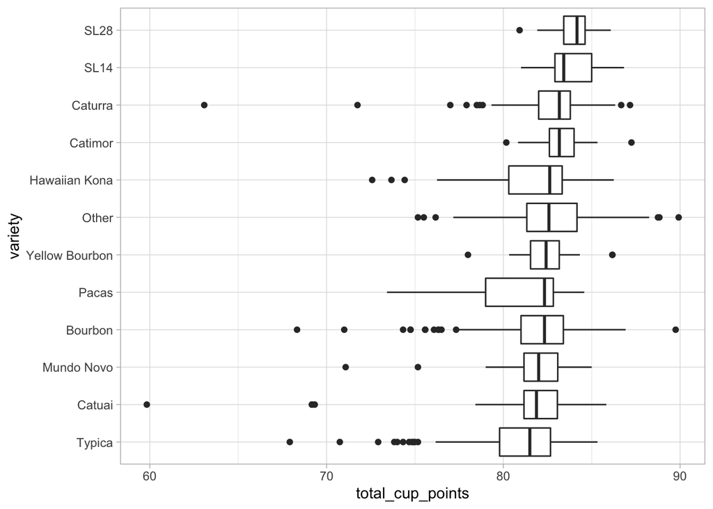

```r
# focus on variety, filter out any of it is missing
coffee_lumped <- coffee_ratings %>%
  filter(!is.na(variety)) %>%
  mutate(variety = fct_lump(variety, 12), # select the top 12 factors
         sort = TRUE)


coffee_lumped %>%
  mutate(
    variety = fct_reorder(
      variety, total_cup_points
      ) # reorder factors in relation to the total cup points
    ) %>%
  ggplot(aes(total_cup_points, variety)) +
    geom_boxplot()
```

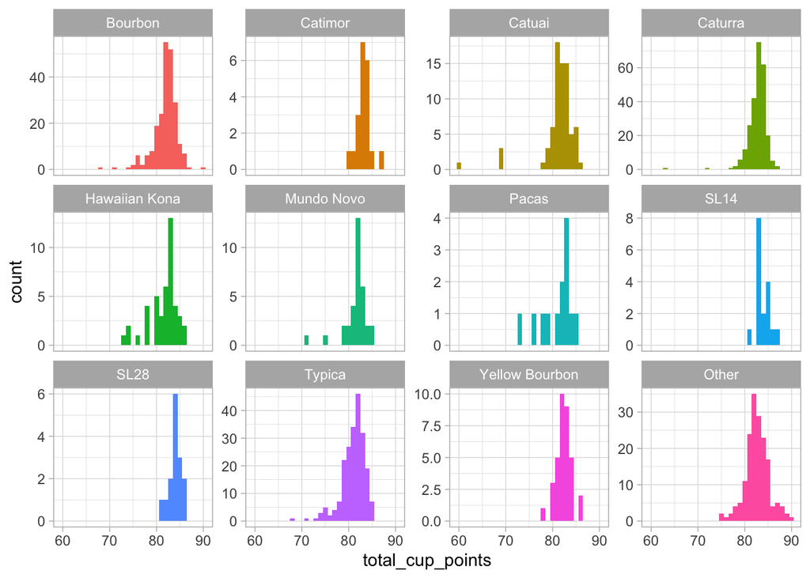

```r
coffee_lumped %>%
  ggplot(aes(total_cup_points, fill = variety)) +
    geom_histogram(binwidth = 1) +
    facet_wrap(~ variety, scale = "free_y") + # adapt y axis to each variety
    theme(legend.position = "none")
```

```r
coffee_ratings %>%
  summarize(
    across(
      everything(), ~ mean(!is.na(.))
      )
    ) %>%
  gather()
```

```
## # A tibble: 44 x 2
##    key               value
##    <chr>             <dbl>
##  1 total_cup_points  1
##  2 species           1
##  3 owner             0.995
##  4 country_of_origin 0.999
##  5 farm_name         0.732
##  6 lot_number        0.206
##  7 mill              0.765
##  8 ico_number        0.887
##  9 company           0.844
## 10 altitude          0.831
## # … with 34 more rows
```

```r
coffee_ratings %>%
  count(producer, sort = TRUE)
```

```
## # A tibble: 692 x 2
##    producer                         n
##    <chr>                        <int>
##  1 <NA>                           231
##  2 La Plata                        30
##  3 Ipanema Agrícola SA             22
##  4 Doi Tung Development Project    17
##  5 Ipanema Agricola                12
##  6 VARIOS                          12
##  7 Ipanema Agricola S.A            11
##  8 ROBERTO MONTERROSO              10
##  9 AMILCAR LAPOLA                   9
## 10 LA PLATA                         9
## # … with 682 more rows
```

```r
coffee_ratings %>%
  count(company, sort = TRUE)
```

```
## # A tibble: 282 x 2
##    company                              n
##    <chr>                            <int>
##  1 <NA>                               209
##  2 unex guatemala, s.a.                86
##  3 ipanema coffees                     50
##  4 exportadora de cafe condor s.a      40
##  5 kona pacific farmers cooperative    40
##  6 racafe & cia s.c.a                  40
##  7 blossom valley宸嶧國際              25
##  8 carcafe ltda                        25
##  9 nucoffee                            24
## 10 taiwan coffee laboratory            20
## # … with 272 more rows
```

```r
coffee_ratings %>%
  count(color, sort = TRUE)
```

```
## # A tibble: 5 x 2
##   color            n
##   <chr>        <int>
## 1 Green          869
## 2 <NA>           218
## 3 Bluish-Green   114
## 4 Blue-Green      85
## 5 None            52
```

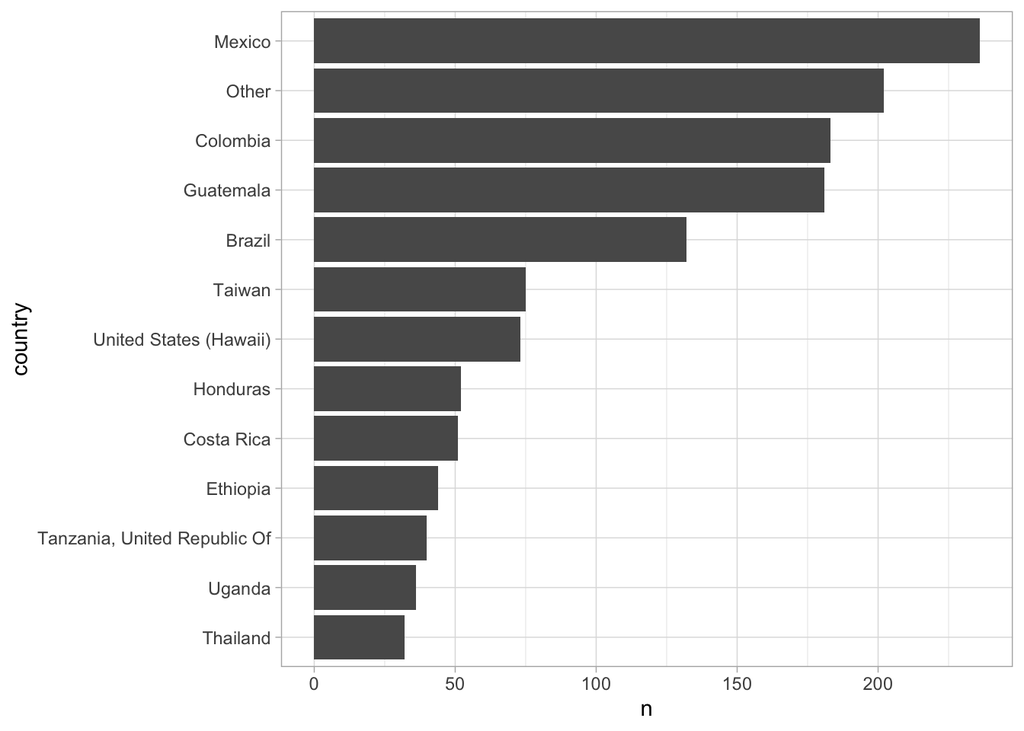

```r
coffee_ratings %>%
  count(country = fct_lump(country_of_origin, 12), sort = TRUE) %>%
  filter(!is.na(country)) %>%
  mutate(country = fct_reorder(country, n)) %>%
  ggplot(aes(n, country)) +
  geom_col()
```

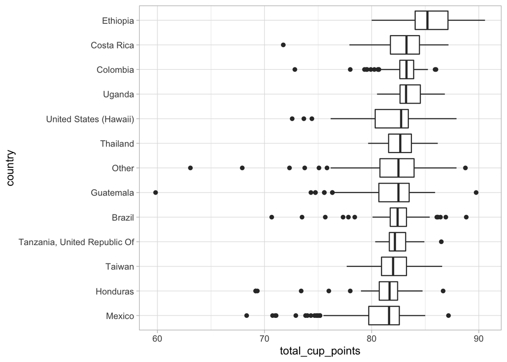

```r
coffee_ratings %>%
  filter(!is.na(country_of_origin)) %>%
  mutate(country = fct_lump(country_of_origin, 12),
         country = fct_reorder(country, total_cup_points)) %>%
  ggplot(aes(total_cup_points, country)) +
  geom_boxplot()
```

Interesting dimensions:

- Country
- Variety
- Company??

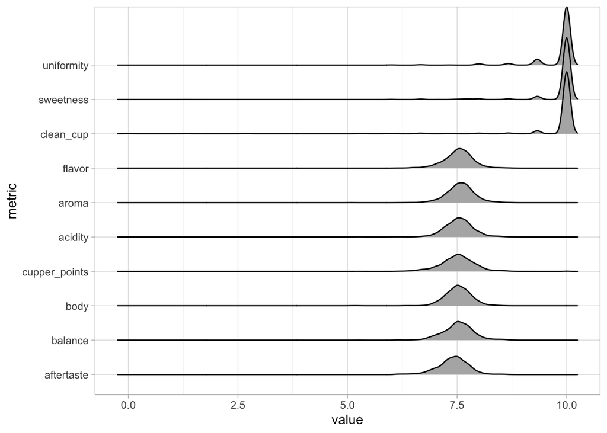

```r
library(ggridges)
coffee_metrics <- coffee_ratings %>%
  select(coffee_id, total_cup_points, variety, company,
         country_of_origin,
         altitude_mean_meters,
         aroma:moisture) %>%
  pivot_longer(aroma:cupper_points, names_to = "metric", values_to = "value")
coffee_metrics %>%
  mutate(metric = fct_reorder(metric, value)) %>%
  ggplot(aes(value, metric)) +
  geom_density_ridges() # geom_density for categorical variables in a dataset
```

```r
coffee_metrics %>%
  group_by(metric) %>%
  summarize(average = mean(value),
            sd = sd(value)) %>%
  arrange(desc(average))
```

```
## # A tibble: 10 x 3
##    metric        average    sd
##    <chr>           <dbl> <dbl>
##  1 sweetness        9.86 0.554
##  2 clean_cup        9.84 0.715
##  3 uniformity       9.84 0.485
##  4 aroma            7.57 0.316
##  5 acidity          7.54 0.319
##  6 flavor           7.53 0.341
##  7 balance          7.52 0.354
##  8 body             7.52 0.308
##  9 cupper_points    7.51 0.427
## 10 aftertaste       7.41 0.350
```

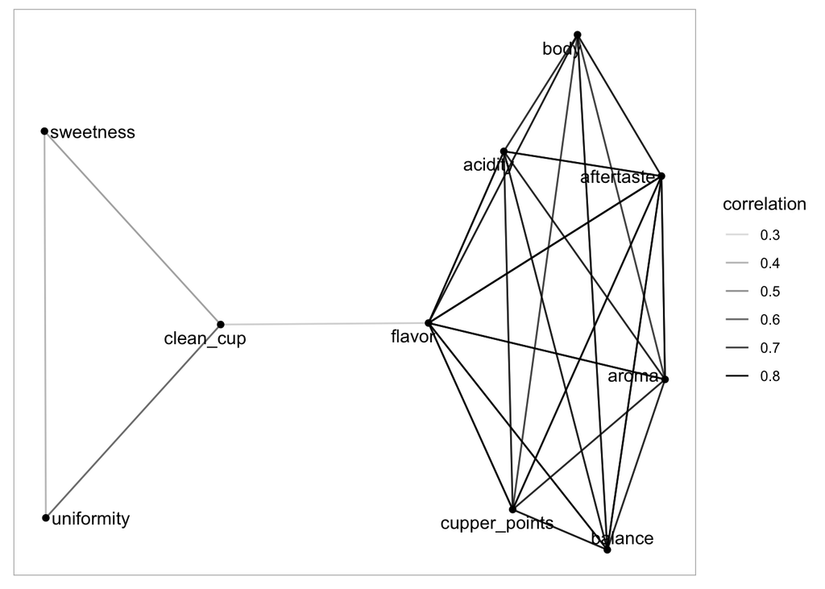

```r
library(widyr) # finds correlation into a messy dataset
library(ggraph) # show network plot to find out clusters
library(igraph)
library(tidytext)
correlations <- coffee_metrics %>%
  # do not understand that step
  pairwise_cor(item = metric, feature = coffee_id, value = value, sort = TRUE)


correlations %>%
  head(50) %>%
  # show clusters between correlated variables
  graph_from_data_frame() %>%
  ggraph() +
    geom_edge_link(aes(edge_alpha = correlation)) +
    geom_node_point() +
    geom_node_text(aes(label = name), repel = TRUE)
```

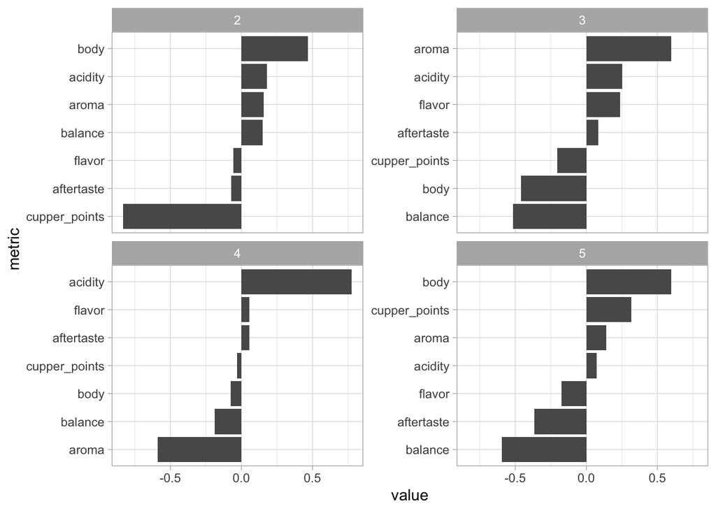

```r
# time to apply a pca
coffee_metrics %>%
  filter(!metric %in% c("sweetness", "clean_cup", "uniformity")) %>%
  group_by(metric) %>%
  mutate(centered = value - mean(value)) %>% # center the values
  ungroup() %>%
  widely_svd(item = metric, feature = coffee_id, value = value) %>%
  filter(between(dimension, 2, 5)) %>%
  mutate(metric = reorder_within(metric, value, dimension)) %>%
  ggplot(aes(value, metric)) +
    geom_col() +
    scale_y_reordered() +
    facet_wrap(~ dimension, scales = "free_y")
```

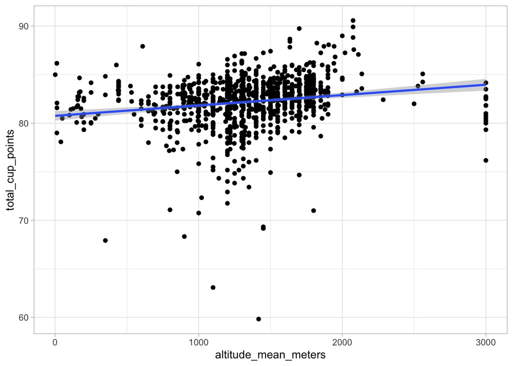

```r
coffee_ratings %>%
  filter(altitude_mean_meters < 10000,
         altitude != 1) %>%
  mutate(altitude_mean_meters = pmin(altitude_mean_meters, 3000)) %>%
  ggplot(aes(altitude_mean_meters, total_cup_points)) +
    geom_point() +
    geom_smooth(method = "lm")
```

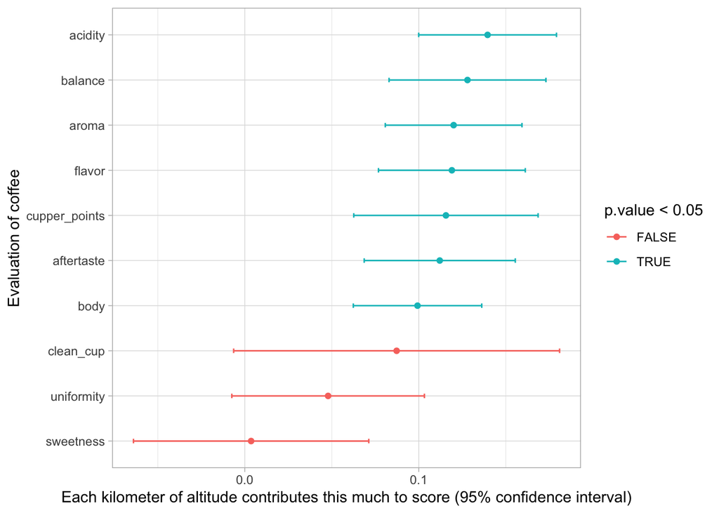

```r
coffee_metrics %>%
  filter(altitude_mean_meters < 10000) %>%
  mutate(altitude_mean_meters = pmin(altitude_mean_meters, 3000)) %>%
  mutate(km = altitude_mean_meters / 1000) %>%
  group_by(metric) %>%
  summarize(correlation = cor(altitude_mean_meters, value),
            model = list(lm(value ~ km))) %>%
  mutate(tidied = map(model, broom::tidy, conf.int = TRUE)) %>%
  unnest(tidied) %>%
  filter(term == "km") %>%
  ungroup() %>%
  mutate(metric = fct_reorder(metric, estimate)) %>%
  ggplot(aes(estimate, metric, color = p.value < .05)) +
  geom_point() +
  geom_errorbarh(aes(xmin = conf.low, xmax = conf.high), height = .1) +
  labs(y = "Evaluation of coffee",
       x = "Each kilometer of altitude contributes this much to score (95% confidence interval)")
```

## Tour de France

```r
# libraries
library(tidytuesdayR)
library(tidyverse)
library(lubridate)
# set plot theme
theme_set(theme_light())
```

```r
tuesdata <- tidytuesdayR::tt_load('2020-04-07')
```

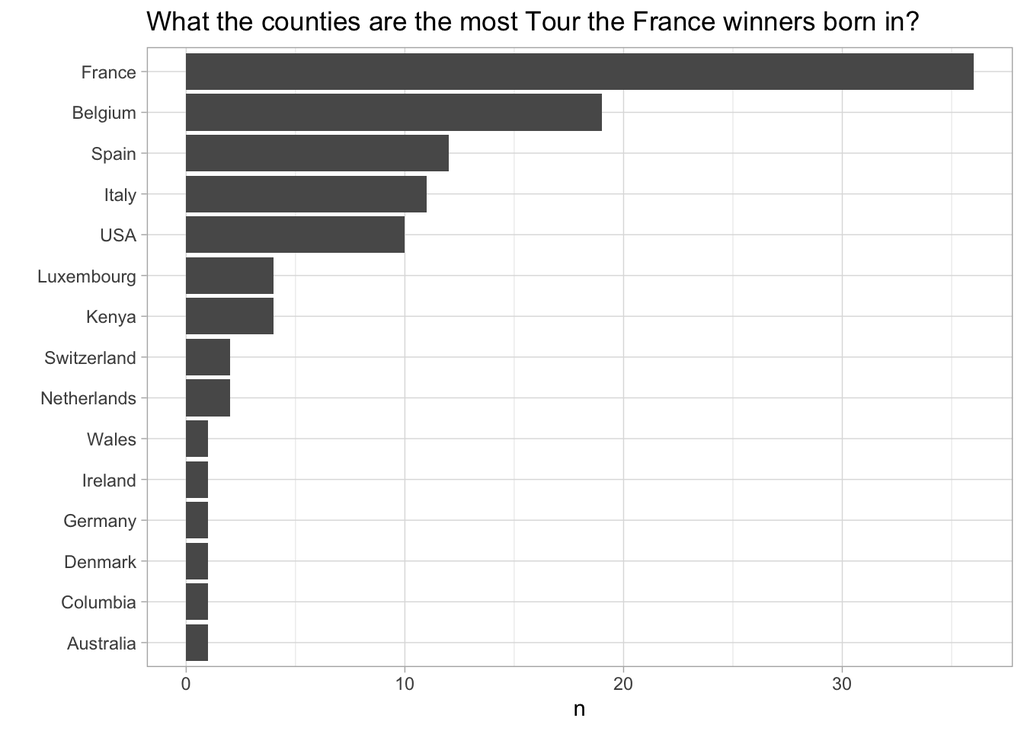

```r
# look at the columns on the dataset
# let's analyse the birth winners
tdf_winners <- tuesdata$tdf_winners %>%
  mutate(year = year(start_date),
         speed = distance / time_overall)

stage_data <- tuesdata$stage_data
tdf_stages <- tuesdata$tdf_stages %>%
  janitor::clean_names() %>% # put all the titles lower
  mutate(year = year(date))

# exploring winners data
tdf_winners %>%
  count(birth_country, sort = TRUE) %>%
  mutate(birth_country = fct_reorder(birth_country, n)) %>%
  ggplot(aes(y = birth_country, x = n)) +
    geom_col() +
    labs(y = "",
         title = "What the counties are the most Tour the France winners born in?")
```

```r
tdf_winners %>%
  count(winner_name, birth_country, sort = TRUE)
```

```
## # A tibble: 63 x 3
##    winner_name      birth_country     n
##    <chr>            <chr>         <int>
##  1 Lance Armstrong  USA               7
##  2 Bernard Hinault  France            5
##  3 Eddy Merckx      Belgium           5
##  4 Jacques Anquetil France            5
##  5 Miguel Induráin  Spain             5
##  6 Chris Froome     Kenya             4
##  7 Greg LeMond      USA               3
##  8 Louison Bobet    France            3
##  9 Philippe Thys    Belgium           3
## 10 Alberto Contador Spain             2
## # … with 53 more rows
```

What has change over time? This question leads to how is the age disitributed over time?

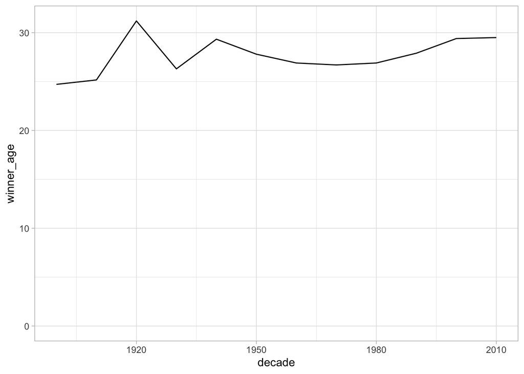

```r
tdf_winners %>%
  group_by(decade = 10 * (year %/% 10)) %>% # truncated division to get the decade
  summarise(winner_age = mean(age),
            winner_height = mean(height, na.rm = TRUE),
            winner_weight = mean(weight, na.rm = TRUE)) %>%
  ggplot(aes(x = decade, y = winner_age)) +
    geom_line() +
    expand_limits(y = 0)
```

There is no clear relation with age, weight or height over the year in the winners.

Now he is looking at the time margin:

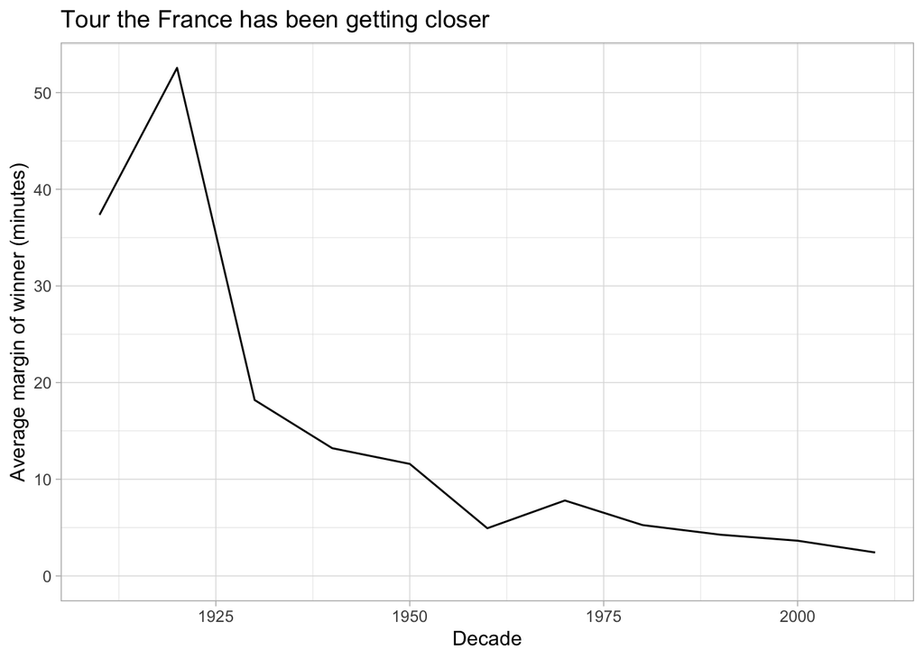

```r
library(lubridate)
by_decade <- tdf_winners %>%
  group_by(decade = 10 * (year %/% 10)) %>% # truncated division to get the decade
  summarise(winner_age = mean(age),
            winner_height = mean(height, na.rm = TRUE),
            winner_weight = mean(weight, na.rm = TRUE),
            winner_margin = mean(time_margin, na.rm = TRUE),
            winner_speed = mean(speed, na.rm = TRUE))

by_decade %>%
  filter(decade >= 1910) %>% # there is only two data points in 1910
  ggplot(aes(x = decade, y = winner_margin * 60)) + # transform to minutes
    geom_line() +
    expand_limits(y = 0) +
    labs(x = "Decade",
         y = "Average margin of winner (minutes)",
         title = "Tour the France has been getting closer")
```

This chart is meaningful.

NOw let’s look at the time of the winner:

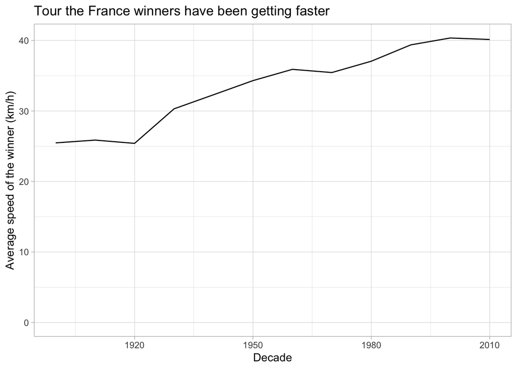

```r
by_decade %>%
  ggplot(aes(x = decade, y = winner_speed)) +
    geom_line() +
    expand_limits(y = 0) +
    labs(x = "Decade",
         y = "Average speed of the winner (km/h)",
         title = "Tour the France winners have been getting faster")
```

They have started to flatter on the paste year, possible doping?. TO know more abou it, I would be looking for some variable that affects the speed, like elevation. But they are on present on the dataset. So now we know with the winners dataset they are getting faster and there are getting closer (less margin time).

Other things, average life expectancy of the winners. To do that, we will do a survivial analyses:

```r
library(survival) # very good for medical proposals
library(broom)

surv_model <- tdf_winners %>%
  distinct(winner_name, .keep_all = TRUE) %>%
  transmute(winner_name,
            birth_year = year(born),
            death_year = year(died),
            dead = as.integer(!is.na(death_year))) %>%
  mutate(age_at_death = coalesce(death_year, 2020) - birth_year) %>% # They are not death, we are just saying they are alive in 2020
  survival::survfit(Surv(age_at_death, dead) ~ 1, data = .)

glance(surv_model)
```

```
## # A tibble: 1 x 10
##   records n.max n.start events rmean rmean.std.error median conf.low conf.high
##     <dbl> <dbl>   <dbl>  <dbl> <dbl>           <dbl>  <dbl>    <dbl>     <dbl>
## 1      63    63      63     38  69.6            2.69     77       71        82
## # … with 1 more variable: nobs <int>
```

Median life expectancy of a Tour of France winner is 77.

Now let’s start some exploration on the stage data:

```r
# I want to join stage data, but I need to prepare them before doing it
stages_joined <- stage_data %>%
  extract(col = stage_results_id,
          into = "stage",
          regex = "stage-(.*)") %>%  # extract anything after "stage"
  inner_join(tdf_stages, by = c("year", "stage")) %>%  # I've lost a little bit of data
  mutate(rank = as.integer(rank)) %>% # NA introduced cause of people not finishing the race
 # add_count(year, stage, name = "competitors") # adding competitors by year and stage
  # now I want to get the number of finishers
  group_by(year, stage) %>%
  mutate(finishers = sum(!is.na(rank))) %>%
  ungroup() %>%
  mutate(percentile = 1 - rank / finishers)

stages_joined %>%
  filter(stage == "1") %>%
  group_by(winner_country) %>%
  summarise(stages = n(),
            median_percentile = median(percentile, na.rm = TRUE)) %>%
  arrange(desc(stages))
```

```
## # A tibble: 18 x 3
##    winner_country stages median_percentile
##    <chr>           <int>             <dbl>
##  1 FRA              3215             0.494
##  2 BEL              2760             0.496
##  3 ITA              1637             0.497
##  4 SUI               800             0.5
##  5 GER               680             0.495
##  6 NED               655             0.498
##  7 GBR               576             0.497
##  8 AUS               387             0.497
##  9 LUX               376             0.496
## 10 EST               368             0.497
## 11 FRG               280             0.496
## 12 CAN               198             0.497
## 13 POR               198             0.497
## 14 SVK               198             0.497
## 15 URS               198             0.497
## 16 USA               189             0.497
## 17 UZB               189             0.497
## 18 ESP               180             0.514
```

This table tell us that no country does it better than the average at the first stage.

How can I find the relation between the results at the first stage and how is affecting at the final results? Does the winner of the first stage predict their final point ranking?

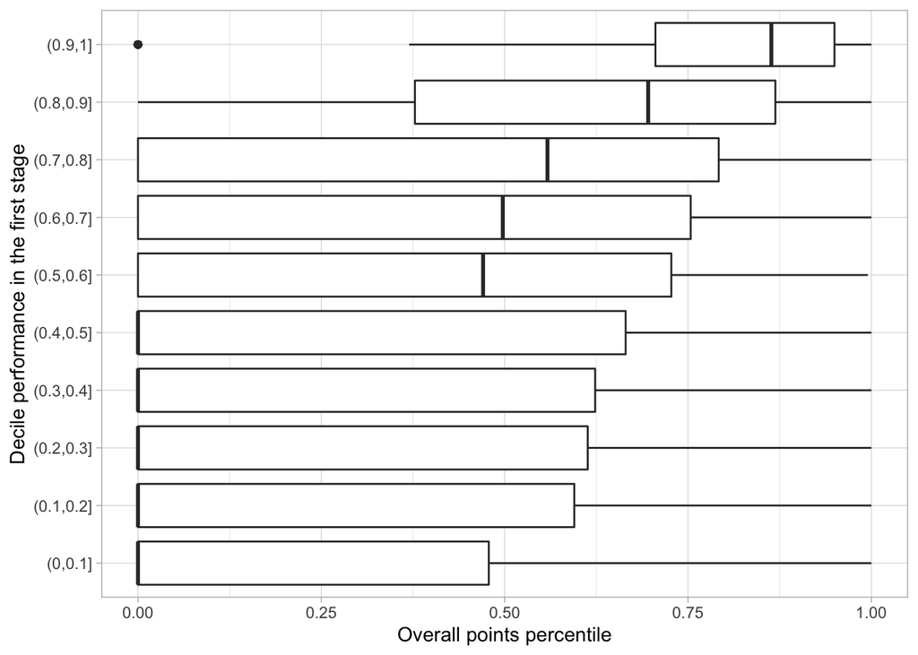

```r
total_points <- stages_joined %>%
  group_by(year, rider) %>%
  summarise(total_points = sum(points, na.rm = TRUE)) %>%
  mutate(points_rank = percent_rank(total_points)) %>%
  ungroup()

stages_joined %>%
  filter(stage == "1") %>%
  inner_join(total_points, by = c("year", "rider")) %>%
  select(year, rider, percentile_first_stage = percentile,
         points_rank) %>%
  mutate(first_stage_bin = cut(percentile_first_stage, seq(0, 1, .1))) %>%
  filter(!is.na(first_stage_bin)) %>%
  ggplot(aes(y = first_stage_bin, x = points_rank)) +
    geom_boxplot() +
    labs(y = "Decile performance in the first stage",
         x = "Overall points percentile")
```

So yes, there is a relation between your results at the first stage and the final results.

Now we are going to use a gganimate to show a race:

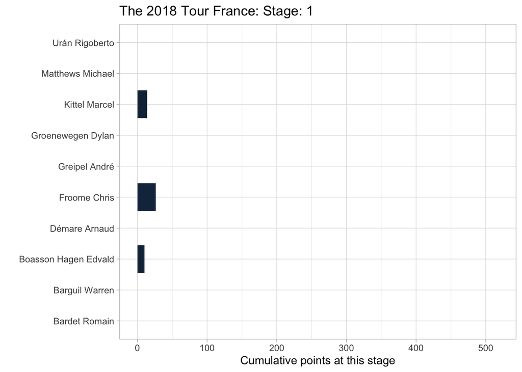

```r
library(gganimate)

top_10_2017 <- total_points %>%
  filter(year == max(year)) %>%
  top_n(10, total_points)

stages_joined %>%
  filter(year == max(year)) %>%
  semi_join(top_10_2017, by = "rider") %>% # now I have all the data for the top 10 riders accross all the time
  mutate(stage = as.integer(stage),
         points = coalesce(points, 0)) %>%
  group_by(rider) %>%
  mutate(cumulative_points = cumsum(points)) %>%
  ungroup() %>%
  ggplot(aes(cumulative_points, rider, fill = cumulative_points)) +
    geom_col() +
    transition_time(stage) +
    theme(legend.position = "none") +
    labs(title = "The 2018 Tour France: Stage: {frame_time}",
         x = "Cumulative points at this stage",
         y = "")
```